# 계리론과 리스크관리론

FIAK, Rate Making

sonsungman https://sonsungman.github.io/SKKU-Preditive.m/  
10-02-2021

### 서론

한국보험계리사 시험은 1차시험과 2차시험으로 구성된다. 2차 과목 중 가장 흥미로운 과목은 단연 계리리스크관리라는 과목이다. 계리론과 리스크관리론 2가지를 합쳐놓은 형태인데 매년 5~6문제에 대한 서술형 답안을 작성하므로 시험을 치루게 된다. 이 글은 각각의 계리론과 리스크관리론의 테마들을 간단하게 정리하는 목적을 갖는다. 참고 서적과 논문은 시중 서적인 황희대 저, 감창기 저, 강계욱 저와 이항석(계리리스크관리 동향) 논문 이다.

### 내 머리 속 목차

계리론은 황희대 저의 목차가 적절하다 생각한다. 설명은 내가 덧붙인것.

- 보험과 보험계리사 (Insurance & actuary) : 민영보험과 사회보험, 보험계리사와 선임계리사제도를 다룬다.
- 보험상품종류 (Product) : 보험상품의 종류, 생명, 손해, 제3보험, 신상품들
- 보험상품개발 (Product development) : 상품개발부서에서 할일들 상품개발전반적인 과정, 위험률 산출, 상품개발시 고려할 다양한 위험들
- 요율 (Pricing) : 일반적인 face value 상품들의 보험료 산출 방법, 실손보상 상품들의 요율 산출 방법
- 준비금 (Reserving) : 보험료 적립금, 지급준비금, 미경과 보험료 적립금, 지급준비금 검증 방법, 보증준비금, 수익성 분석
- 손익 및 배당 (Profit) : 손익분석, 배당관련적립금
- 부채평가 (Valuation) : IFRS17과 EV 주제를 주로 다룸

리스크관리론 또한 황희대 저 의 목차가 적절하다 생각한다. 대부분 비슷하다.

- 리스크 : 리스크 정의, 도덕적 해이와 역선택, ERM, 기대효용이론
- 보험리스크 : 장수리스크, 보험리스크의 원천 등
- 보험리스크 전가 : 전통적 수단(재보험), 자기부담금, 다양한 조항들, ART
- 금리리스크 : 정의, 원천, 이자율 기간구조론, 후순위채 및 신종자본증권, 관리 전략
- 시장리스크 : VAR, 스트레스 테스트, 다양한 원천, 운영리스크까지
- 지급여력제도 (RBC & K-ICS) : 지급여력제도의 역사, 계수방식 측정, k-ICS, Solvency2, ORSA, RAAS

### 요율 산정에 관하여

Face value를 갖는 상품에 관하여 일반적인 보험수리적 보험료 산출 방법이 적용된다. 위험률과 이자율, 사업비를 활용한 3이원 방식의 보험료 산출을 하는 것이다. 실무적인 측면에서도 시산보험료의 경우 3이원방식을 활용하고 이후 현금흐름방식을 활용하여 수익성 분석등을 한다. 실손 보상 상품의 요율 산정 방식은 다르게 구성된다. 보통 rate making 이라고 할 수 있는데 대표적으로 자동차 보험료, 기업성 보험 상품의 요율 산정이 이러한 방식으로 이루어진다. FIAK의 경우 계리모형론이라는 과목에서 단기 상품의 요율 산정에 관한 이론을 다루며 SOA는 STAM, CAS는 EXAM 5에서 다룬다. 보통 Basic한 수준에서 다루며 Advanced한 주제는 한국시험에서 커버하지 못한다. SOA의 팰로우 과정인 GI 트랙(내가 취득하고자하는 트랙)에서 CAS는 팰로우 과정인 EXAM 8에서 다룬다.

### 읽어야 할 자료(내가)

[figure not shown]

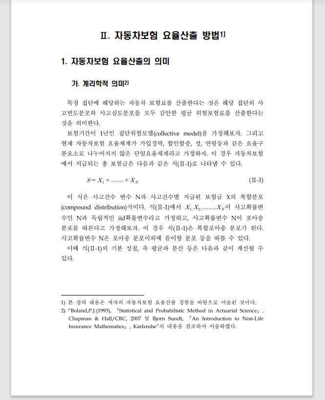